# Unmixing Script

Author

Ayrianna Hedgecock; UNC FCCF

# Background

This script is created for **Caroline Stockwell** by Ayrianna Hedgecock at UNC FCCF. The script will take raw spectral FCS files and unmix them.

# Set up

Load necessary packages

## environment initialization

```r
renv::restore()
renv::status()
renv::dependencies()
```

### To-Dos

- enviornment init/ package checklist to transfer to new computer
- update output folder for figures in AutoSpectral
- Update and move ALL `file.paths()` to the file.paths code block

```r
library(tidyverse)
library(AutoSpectral)
library(AutoSpectralRcpp)
library(Luciernaga)
library(openCyto)
library(flowWorkspace)
library(flowGate)
```

- Update the `file.path()` if needed
- Place all the single color controls in the folder labelled “SCC”
- Place all samples in the folder labelled “Samples”

```r
# folder locations
outputfolder <- file.path("Output")
datafolder <- file.path("Data")
singlecolorcontrolsfolder <- file.path(datafolder, "SCC")
samplesfolder <- file.path(datafolder, "Samples")
unmixed_folder <- file.path(datafolder, "AutoSpectral_unmixed")

# Patient samples
Patient_unstained_samples <- list.files(
    singlecolorcontrolsfolder,
    pattern = "PT",
    full.names = TRUE,
    ignore.case = TRUE
)
```

# AutoSpectral

Set the spectral cytometer settings

```r
asp <- get.autospectral.param(cytometer = "aurora")
```

```
Cytometer set to Aurora
```

### Create a control file

There is a ShinyApp to help with the control process. ONLY one (1) “AF” sample can be identified. This should be that patient the matrix will be used for.

```r
shiny::runApp(appDir = datafolder, launch.browser = TRUE)
```

This file was saved to the Data Folder initally, then manually moved to the Outputs folder (during testing)

To do this the Manual Way:

```r
control.dir <- file.path(singlecolorcontrolsfolder)
control_filename <- "fcs_control_file_Shiny" # change as desired or leave as default
```

```r
create.control.file(
  control.dir,
  asp,
  output.dir = outputfolder,
  filename = control_filename
)
```

If fluorophores exist in the `AutoSpectral` database they will be autofilled in the contol .csv. If not, you will need to manually add it in.

Structure of the Control File

See Control File information here: [Control File- AutoSpectral](https://drcytometer.github.io/AutoSpectral/articles/02_Control_File_example.html) The main structural elements to the control file are the following columns. Note, we will be using the `get.spectra.automated()` function, so the “legacy” columns are not needed. Read more in linked article.

- **filename**: The actual .fcs filename
- **fluorophore**: The name of the fluorophore (or AF in case of the unstained)
- **marker**: The name of the marker (or left empty in the case of the unstained)
- **channel**: The peak detector channel of the fluorophore (left empty for the unstained).
- **control.type**: Whether the unmixing control is cells or beads (used for matching positive and negatives for background subtraction)
- **universal.negative**: By default empty, if you want to use an universal negative, copy the filename of the corresponding unstained into this spot on a per fluorophore basis
- large.gate: Logical value, by default FALSE, set to TRUE to expand the gating area
- gate.name: Gate name for use in signature retrievel
- gate.define: Logical, permits you to set the general gate region as defined by gate.name
- is.viability: Whether your control is a viability dye.

Edit the file as necessary. I find this easiest within the .csv rather than programtically in R. In the future, we can add programtic edits.

Now that the control file has been edited, lets maunally save it with the **“_updated”** suffix so it doesn’t get overwritten in future runs of this script.

### Validate control file

This only needs to be done if the Shiny App was **NOT** used. QC the control file:

```r
control_filename_updated <- paste0(
  "Output/",
  control_filename,
  "_updated",
  ".csv"
)
control_filename_updated
```

```
[1] "Output/fcs_control_file_Shiny_updated.csv"
```

```r
issues <- check.control.file(
  control.dir,
  control.def.file = control_filename_updated,
  asp
)
```

### Spectral Extraction

Let’s clean and extract our signatures

```r
spectra <- get.spectra.automated(
  control.dir,
  control.def.file = control_filename_updated,
  asp
)
```

Figures are automatically created to QC this process. This should be a stopping point to ensure all looks good!

### ADD A PRESENTATION OR PDF REPORT WITH IMPORTANT FIGURES GENERATED.

## Unmixing

Let’s create a “flow.control” object to feed dye names and markers into unmixing

```r
flow_control <- reload.flow.control(control.dir, control_filename_updated, asp)
spectra_folder <- list.files("table_spectra")
spectra <- read.spectra(spectra.file = spectra_folder[1]) # to call spectra file back into R if needed
```

This is a complicated sample, let’s leverage the per-cell and per-fluorophore extraction to get best unmixing we can.

Let’s start with the AF extractions per pt

```r
Patient_unstained_samples <- list.files(
  singlecolorcontrolsfolder,
  pattern = "PT",
  full.names = TRUE,
  ignore.case = TRUE
)
```

```r
patient_af <- get.af.spectra(
  unstained.sample = Patient_unstained_samples[1],
  asp = asp,
  spectra = spectra
)
```

```r
af_file <- list.files("table_spectra")
patient_af <- read.spectra(spectra.file = af_file[4])
```

Test went well, let’s move to per-cell fluorophore optimization

### ADD PRESENTATAION/REPORT TO VIEW AF SIGNATURES

```r
fluorophore_variants <- get.spectral.variants(
  control.dir = control.dir,
  control.def.file = control_filename_updated,
  asp = asp,
  spectra = spectra,
  output.dir = outputfolder
)
```

```r
spectral_variants_RDS <- list.files(
  outputfolder,
  pattern = ".RDS",
  full.names = TRUE,
  ignore.case = TRUE
)
fluorophore_variants <- read_rds(spectral_variants_RDS)
```

Now, let’s put both pieces together to do the final unmix

### ADD PRESENTATION/REPORT TO VIEW FLUOROPHORE VARIANTS

```r
Patient_sample <- list.files(samplesfolder, full.names = TRUE)

unmix.fcs(
  fcs.file = Patient_sample[1], #one example
  spectra = spectra,
  asp = asp,
  flow.control = flow_control,
  method = "AutoSpectral",
  af.spectra = patient_af,
  spectra.variants = fluorophore_variants,
  speed = "slow",
  output.dir = unmixed_folder
)
```

Now that we’ve completed the unmixing of one file, let’s check our work!

# QC unmixing

## automated gating set up

Let’s do some basic clean up gates prior to visualizing the NxN plot

See how to write the gating Template [here](https://www.bioconductor.org/packages/3.24/bioc/vignettes/openCyto/inst/doc/HowToWriteCSVTemplate.html)

```r
GatingFolder <- file.path("openCytoGate")
CleanUpGatingTemplateFile <- list.files(
  GatingFolder,
  pattern = ".csv",
  full.names = TRUE
)
cleanup_gates <- data.table::fread(CleanUpGatingTemplateFile)
Template <- gatingTemplate(cleanup_gates)
```

```
Adding population:cells
```

```
Adding population:singletsFSC
```

```
Adding population:singletsSSC
```

### GatingSet and Transformation

```r
# locate unmixed files
unmixed_files <- list.files(unmixed_folder, full.names = TRUE)

unmixed_files
```

```
[1] "Data/AutoSpectral_unmixed/11 PT169 immune panel AutoSpectral.fcs"
```

```r
# load in as a cytoset
patient_cytoset <- load_cytoset_from_fcs(
  unmixed_files,
  truncate_max_range = FALSE,
  transformation = FALSE
)

# create GatingSet for gates
patient_GS <- GatingSet(patient_cytoset)
```

```r
# list of fluorophores in files
parameters <- colnames(patient_GS)
flurophores_only <- parameters[!str_detect(parameters, "Time|FSC|SSC|Index")]
flurophores_only
```

```
 [1] "BUV395-A"              "BUV615-A"              "BUV805-A"
 [4] "BV421-A"               "BV711-A"               "BB515-A"
 [7] "RB613-A"               "RB705-A"               "RB780-A"
[10] "PE-A"                  "RY655-A"               "RY703-A"
[13] "PE-Cy7-A"              "APC-A"                 "APC-H7-A"
[16] "Helix NP Blue-A"       "Live Dead Nir (876)-A" "AF-A"
```

```r
# transformation
Biexponential <- flowjo_biexp_trans(
  channelRange = 4096,
  maxValue = 262144,
  pos = 4.5,
  neg = 0,
  widthBasis = -1000
)
BiexTransformList <- transformerList(flurophores_only, Biexponential)

transform(patient_GS, BiexTransformList)
```

```
A GatingSet with 1 samples
```

```
$`1`
```

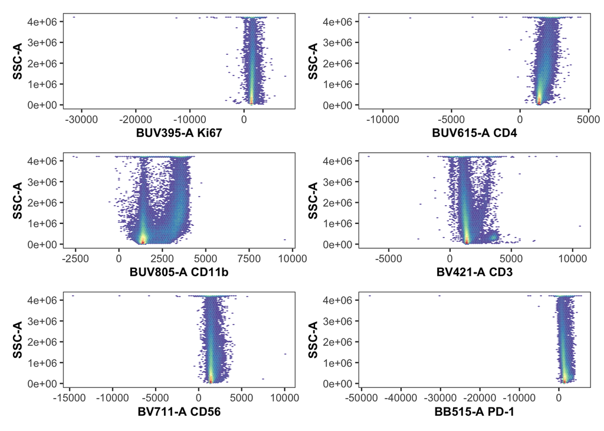

```
$`2`
```

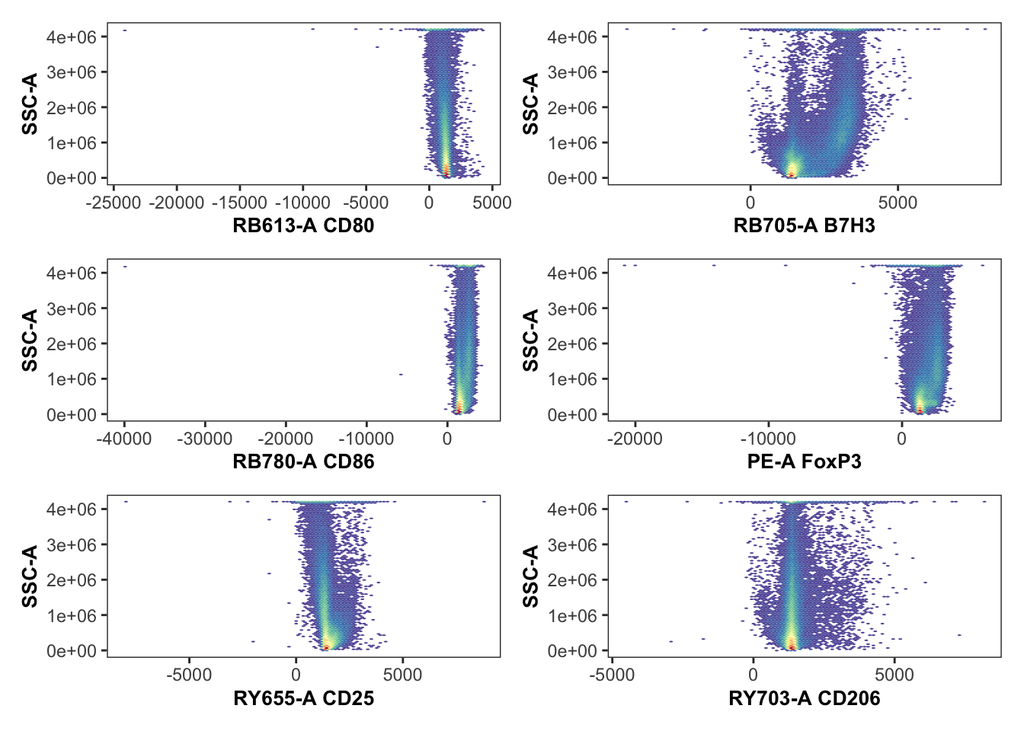

```
$`3`
```

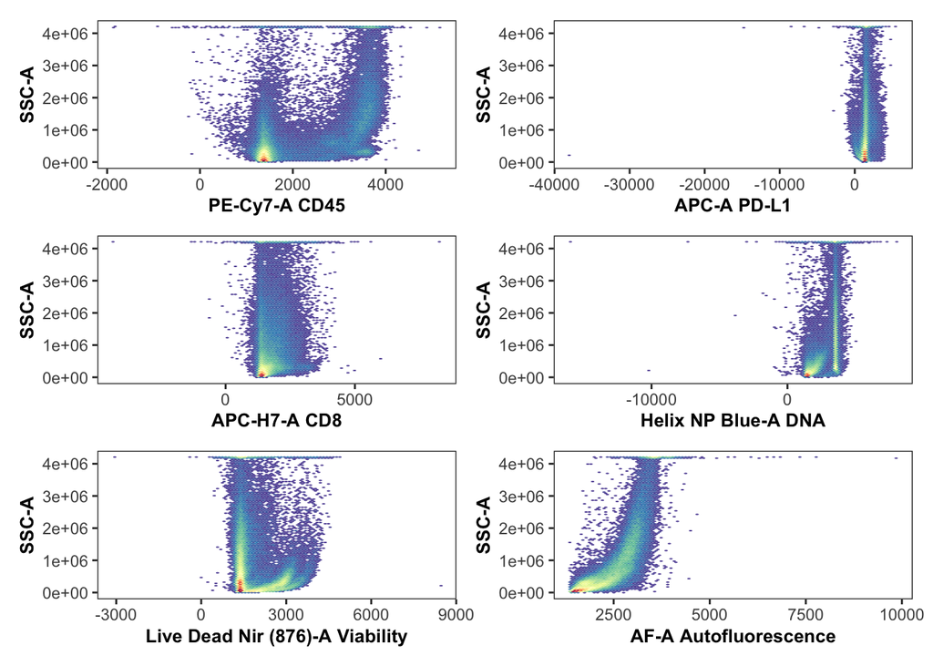

```
$`4`
```

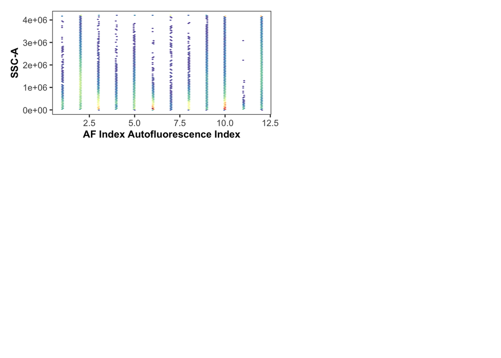

```r
Luciernaga::Utility_NbyNPlots(
    patient_GS,
    sample.name = "GUID",
    outpath = outputfolder,
    ycolumn = "SSC-A",
    returntype = "patchwork"
)
```

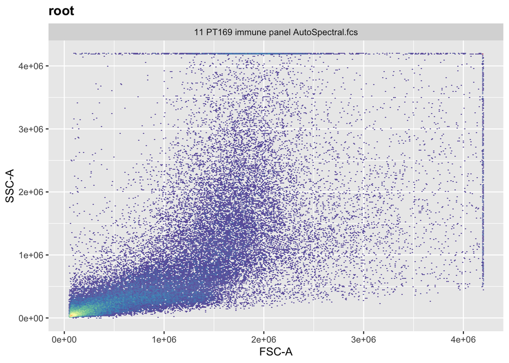

```r
ggcyto::ggcyto(patient_GS[1], subset = "root", aes(x = "FSC-A", y = "SSC-A")) +
    geom_hex(bins = 300)
```

### Apply automated gating scheme

```r
gt_gating(Template, patient_GS)
```

```
Gating for 'cells'
```

```
done!
```

```
done.
```

```
Gating for 'singletsFSC'
```

```
done!
```

```
done.
```

```
Gating for 'singletsSSC'
```

```
done!
```

```
done.
```

```
finished.
```

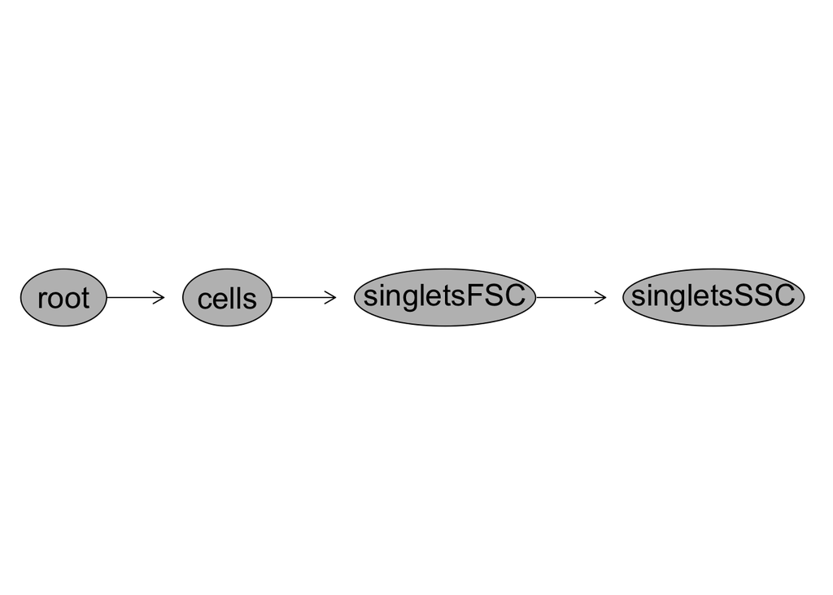

```r
plot(patient_GS)
```

```
$`1`
```

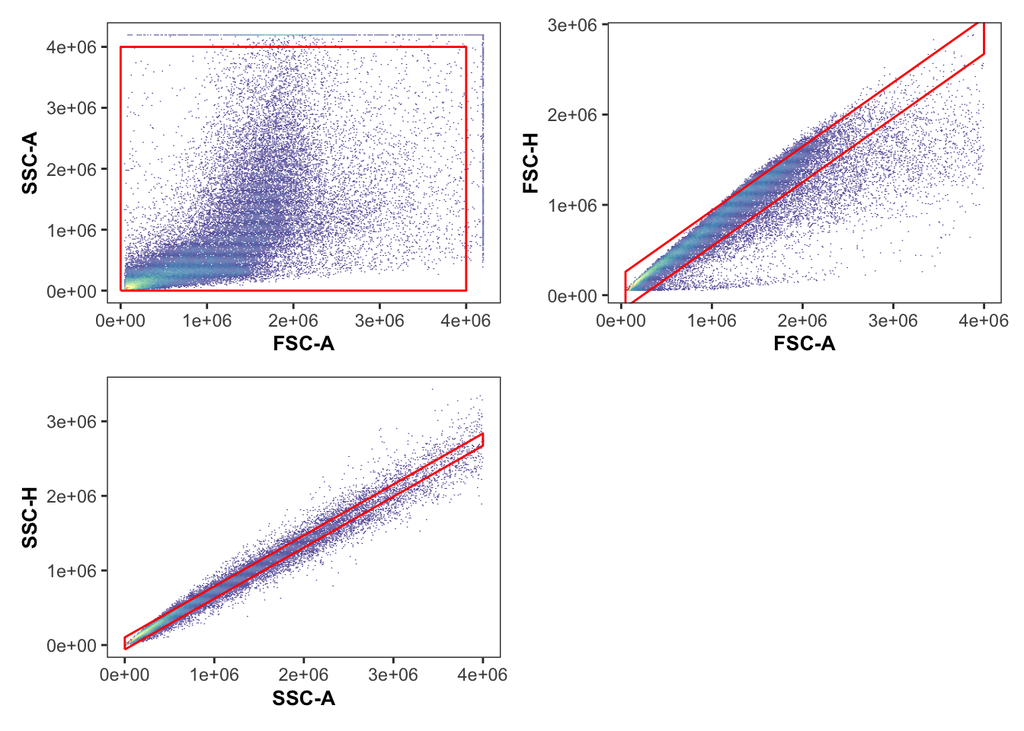

```r
Utility_GatingPlots(
  patient_GS,
  sample.name = "GUID",
  gtFile = cleanup_gates,
  returnType = "patchwork",
  removestrings = ".fcs"
)
```

The gating is okay… let’s see if we can adjust them.

### Adjust gates as needed

Let’s try a manual cleanup gate

The “singletsFSC” is too narrow for me - let’s adjust

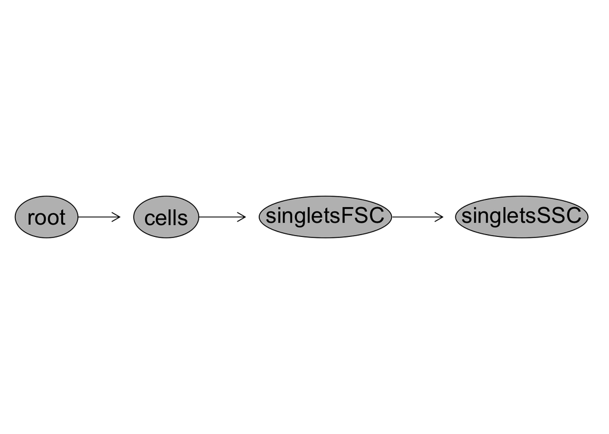

```r
plot(patient_GS)
```

```r
gs_gate_interactive_adjust(
  gs = patient_GS,
  gate = "singletsFSC",
  sample = 1,
  AdjustAll = TRUE
)

Utility_GatingPlots(
  patient_GS,
  sample.name = "GUID",
  gtFile = cleanup_gates,
  returnType = "patchwork",
  removestrings = ".fcs"
)
```

```r
gs_save_path <- file.path(outputfolder, "GatingSet")
save_gs(patient_GS, path = gs_save_path)

load_gs(gs_save_path)
```

## NxN plots

Okay, I am happy with these gates. Now that they are applied, lets see the NxN plot

```
$`1`
```

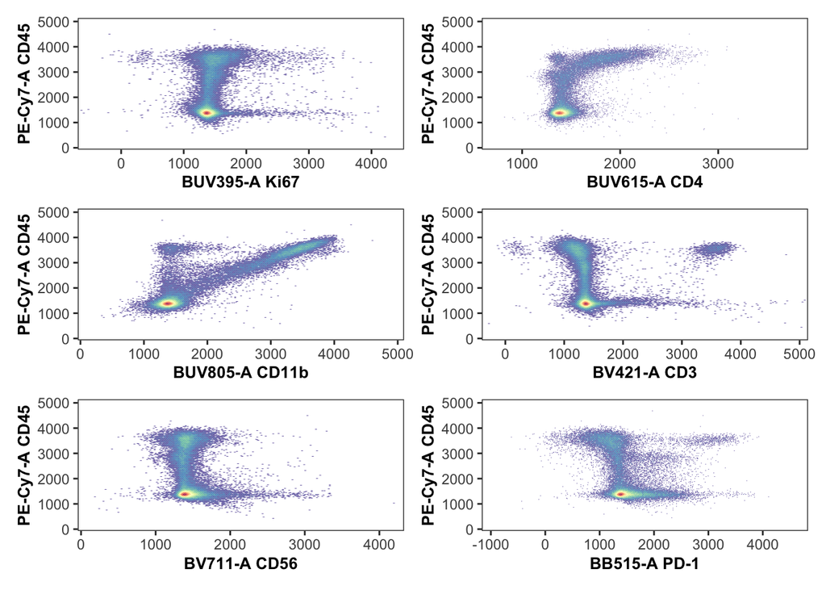

```
$`2`
```

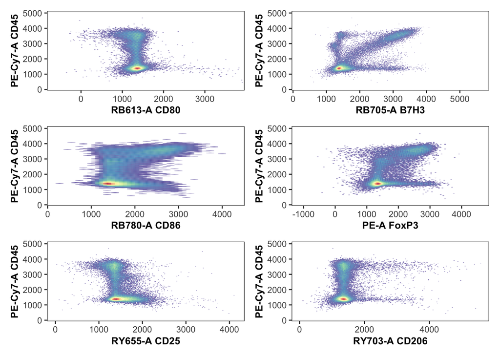

```
$`3`
```

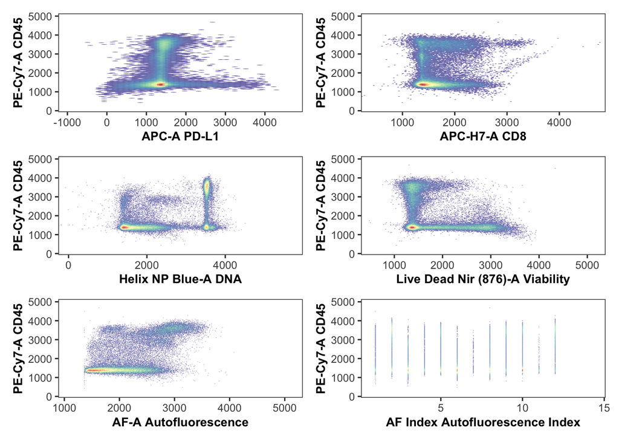

```r
Utility_NbyNPlots(
  patient_GS,
  sample.name = "GUID",
  gatesubset = "singletsSSC",
  ycolumn = "PE-Cy7-A",
  bins = 300
)
```

## CompensAID package

Is the comepsAID package useful?

```r
gated_data_flowframe <- gh_pop_get_data(
  patient_GS[[1]],
  y = "singletsSSC",
  inverse.transform = FALSE
)

ff <- cytoframe_to_flowFrame(gated_data_flowframe)

ff[, names(markernames(ff))]
```

```
flowFrame object '11 PT169 immune panel AutoSpectral.fcs'
with 66488 cells and 19 observables:
                      name                   desc     range  minRange  maxRange
$P11              BUV395-A                   Ki67   10017.7    1344.3   10017.7
$P12              BUV615-A                    CD4   10017.7    1344.3   10017.7
$P13              BUV805-A                  CD11b   10017.7    1344.3   10017.7
$P14               BV421-A                    CD3   10017.7    1344.3   10017.7
$P15               BV711-A                   CD56   10017.7    1344.3   10017.7
...                    ...                    ...       ...       ...       ...
$P25              APC-H7-A                    CD8   10017.7    1344.3   10017.7
$P26       Helix NP Blue-A                    DNA   10017.7    1344.3   10017.7
$P27 Live Dead Nir (876)-A              Viability   10017.7    1344.3   10017.7
$P28                  AF-A       Autofluorescence   10017.7    1365.0   10017.7
$P29              AF Index Autofluorescence Index      11.0       0.0      11.0
343 keywords are stored in the 'description' slot
```

```r
library(CompensAID)
```

```r
compensaid_results <- CompensAID(ff)
```

```
Importing sample: /Users/ayrianna/Documents/Caroline_Rproj_FlowCore/Data/AutoSpectral_unmixed/11 PT169 immune panel AutoSpectral.fcs
```

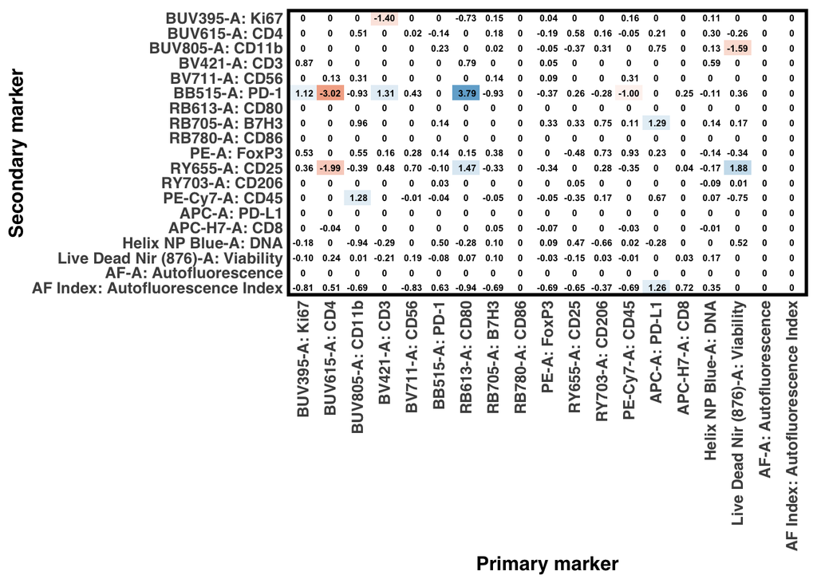

```r
compensaid_matirx <- PlotMatrix(compensaid_results)
compensaid_matirx
```

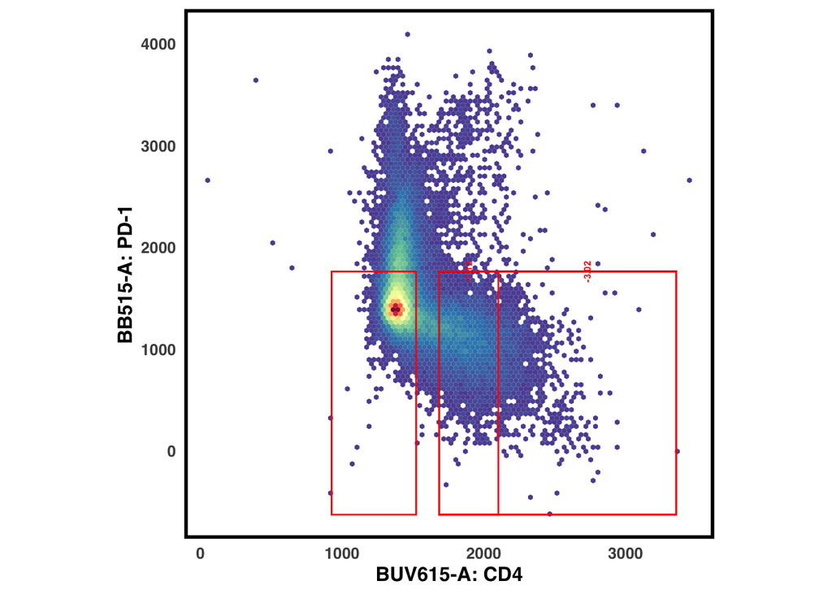

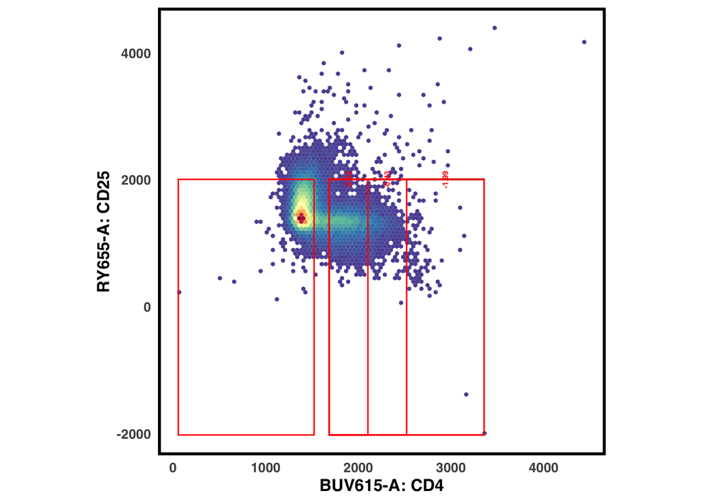

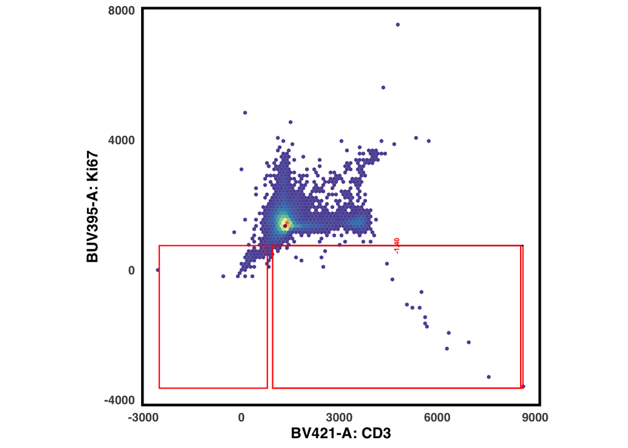

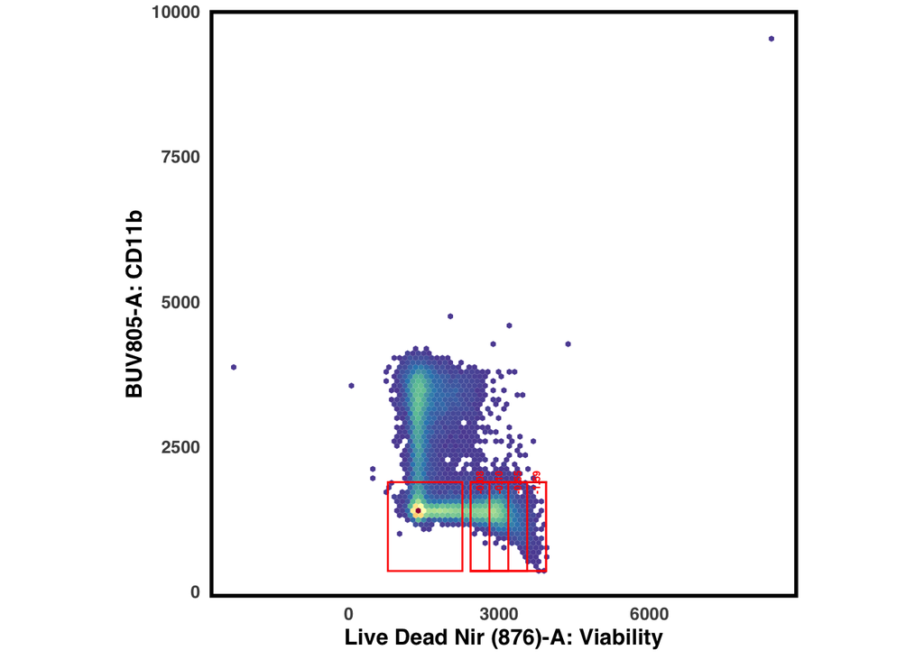

```r
# Check SSI < -1
index <- which(compensaid_results$matrix < -1, arr.ind = TRUE)

combination <- data.frame(
  primary.channel = rownames(compensaid_results$matrix)[index[, "col"]],
  secondary.channel = rownames(compensaid_results$matrix)[index[, "row"]]
) |>
  mutate(
    primary.marker = markernames(ff)[primary.channel],
    secondary.marker = markernames(ff)[secondary.channel]
  )

compensaid_plots <- pmap(
  combination[c("primary.marker", "secondary.marker")],
  \(primary.marker, secondary.marker) {
    PlotDotSSI(
      compensaid_results,
      ff,
      primary = primary.marker,
      secondary = secondary.marker,
      showScores = TRUE
    )
  }
)

walk(compensaid_plots, print)
```

This is potentially very powerful!

# Environment Information

```r
renv::snapshot()
```